# Replication of ‘Does Seeing Faces of Young Black Boys Facilitate the Identification of Threatening Stimuli?’ by Todd, Thiem, & Neel (2016, Psychological Science)

Cinoo Lee (cinoolee@stanford.edu)

2017.03

## Introduction

We will try to replicate the following result from the original study:

“Pervasive stereotypes linking Black men with violence and criminality can lead to implicit cognitive biases, including the misidentification of harmless objects as weapons. [..] We investigated whether these biases extend even to young Black boys (5-year-olds). Results [revealed] that participants had less difficulty (i.e., faster response times, fewer errors) identifying threatening stimuli and more difficulty identifying nonthreatening stimuli after seeing Black faces than after seeing White faces.” (Todd et al., 2016)

## Methods

“White participants completed sequential priming tasks in which they categorized threatening and nonthreatening objects (toys and guns) and words after brief presentations of Black and White children’s faces.”

### Power Analysis

Original $\sf{η_{p}}$<sup>2</sup> = .22 which translates into an effect size of 0.53. Power analysis shows that I need 16 participants for 80% power, 20 for 90%, and 24 for 95% power. This effect size is for the 2 (race of prime: Black, White) × 2 (target object: gun, toy) repeated measures analysis of variance (ANOVA).

### Planned Sample

Other - Planned sample size is 37. 99% power yields n = 32 and we added 5, which is 15% of 32 to ensure we will still have enough participants after the exclusion criteria. We will exclude non-White participants in the analysis.

### Materials

“The primes were 12 photos of boys (6 Black, 6 White) taken from the Child Affective Facial Expression set (LoBue & Thrasher, 2015). We selected these photos using the following criteria: The faces had to be easily categorized by race, to have a neutral expression, to have no idiosyncrasies (e.g., facial scars), and to be similar in actual age (mean age for Black faces = 4.98 years; mean age for White faces = 5.01 years; p > .250). Each photo was cropped so that it included only the head and was standardized in size. The target objects were 6 gun images taken from Payne (2001) and 6 toy images (e.g., a rattle) taken from online sources. The toy images were converted to gray scale and sized to match the gun images.”

### Procedure

Instead of beginning with a blank screen (500 ms) like in the original article, we began with a screen that instructed participants to “Press the spacebar to continue” after each trial. The rest of the procedures were the same. “Each trial sequence began [..] followed by a face prime (200 ms), then a target object (200 ms), and finally a pattern mask (which remained on screen until participants responded). If participants did not respond within 500 ms, a message (“Please respond faster!”) appeared for 1 s. Each of the 12 face primes was paired once with each of the 12 target objects, which resulted in 144 randomly ordered experimental trials. Eight practice trials preceded the experimental trials.”

### Analysis Plan

“We decided a priori to exclude data from participants with below-chance accuracy (i.e., errors on > 50% of trials) on the weapon identification task.”

“Before analysis, we excluded errors and RTs less than 100 ms. RTs exceeding the 500-ms deadline were excluded from analyses, and responses on those trials were treated as errors. We then subjected the remaining RTs to a log transformation (Payne, 2001); however, for interpretive ease, we report raw RTs. A 2 (race of prime: Black, White) × 2 (target object: gun, toy) repeated measures analysis of variance (ANOVA) revealed a significant interaction.” The key test will be the interaction effect of this 2 X 2 ANOVA.

We will only analyze data from people who indicated their race as White.

### Differences from Original Study

Difference in procedure is noted above. Instead of a lab study, this study will be conducted online. These differences are not anticipated to make a difference in the effect.

## Results

### Data preparation

```r
###Exclusion
#Exclude non-White participants
d.white <- d %>%
  filter(Ethnicity == "Caucasian/White")

length(unique(d.white$workerid))
```

```
## [1] 26
```

```r
#assess accuracy of people among those who have responded to the question
assess_accuracy  <- d %>%
  filter(responded==1) %>%
  group_by(workerid) %>%
summarise(mean_accuracy = mean(accuracy))

#assess n of participants who are 50% accuracy or higher
assess_accuracy  <- d %>%
  filter(responded==1) %>%
  group_by(workerid) %>%
  summarise(mean_accuracy = mean(accuracy)) %>%
  filter(mean_accuracy > 0.499)
#this comes out to be 21 people for all ethnicity and 16 people for Whites.
#adjusting the filter to 40% or higher makes everyone pass the bar.

d.complete.all <- d %>%
   filter(!(is.na(rt)) & accuracy == 1 & rt > 100 &  rt <= 500) %>%
   mutate(log_rt = log(rt))

d.complete.white <- d.white %>%
  filter(!(is.na(rt)) & accuracy == 1 & rt > 100 &  rt <= 500) %>%
   mutate(log_rt = log(rt))
```

### Plotting Preparation

```r
sem <- function(x) {sd(x) / sqrt(length(x))}

ci95.norm <- function(x) {
  me <- sem(x)*qnorm(.975)
  c(mean(x)-me, mean(x)+me)
}

means.all <- d.complete.all %>%
  filter(accuracy == 1) %>% #only want correct trials
  filter(!is.na(rt)) %>%
  group_by(workerid, targetRace, toolType) %>%
  summarise(participant_mean = mean(rt)) %>%
  group_by(targetRace, toolType, add=FALSE) %>%
  summarise(m = mean(participant_mean), ci.lo=ci95.norm(participant_mean)[1], ci.hi = ci95.norm(participant_mean)[2])

means.white <- d.complete.white %>%
  filter(accuracy == 1) %>% #only want correct trials
  filter(!is.na(rt)) %>%
  group_by(workerid, targetRace, toolType) %>%
  summarise(participant_mean = mean(rt)) %>%
  group_by(targetRace, toolType, add=FALSE) %>%
  summarise(m = mean(participant_mean), ci.lo=ci95.norm(participant_mean)[1], ci.hi = ci95.norm(participant_mean)[2])

limits = aes(ymax=ci.hi, ymin=ci.lo)
```

### Confirmatory analysis

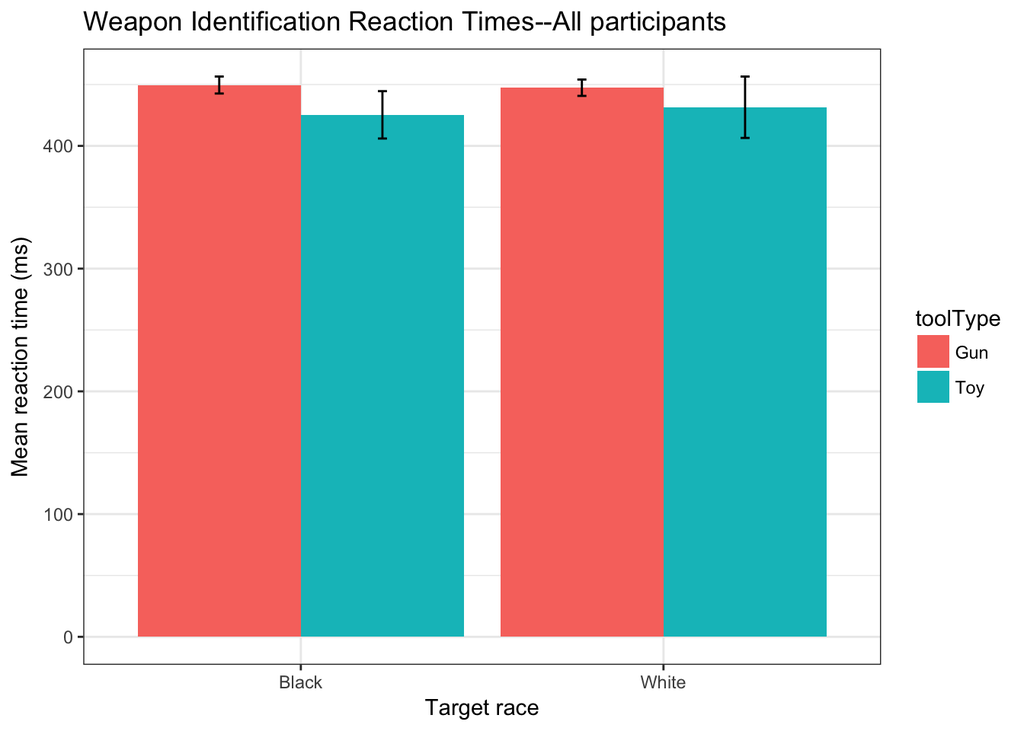

```r
ggplot(means.all, aes(x=targetRace, y=m, fill=toolType)) +
  geom_bar(stat="identity", position="dodge", width=.9) +
  geom_errorbar(limits, position=position_dodge(width=.9), width=0.05) +
  theme_bw() +
  ggtitle("Weapon Identification Reaction Times--All participants") +
  labs(x = "Target race", y = "Mean reaction time (ms)")
```

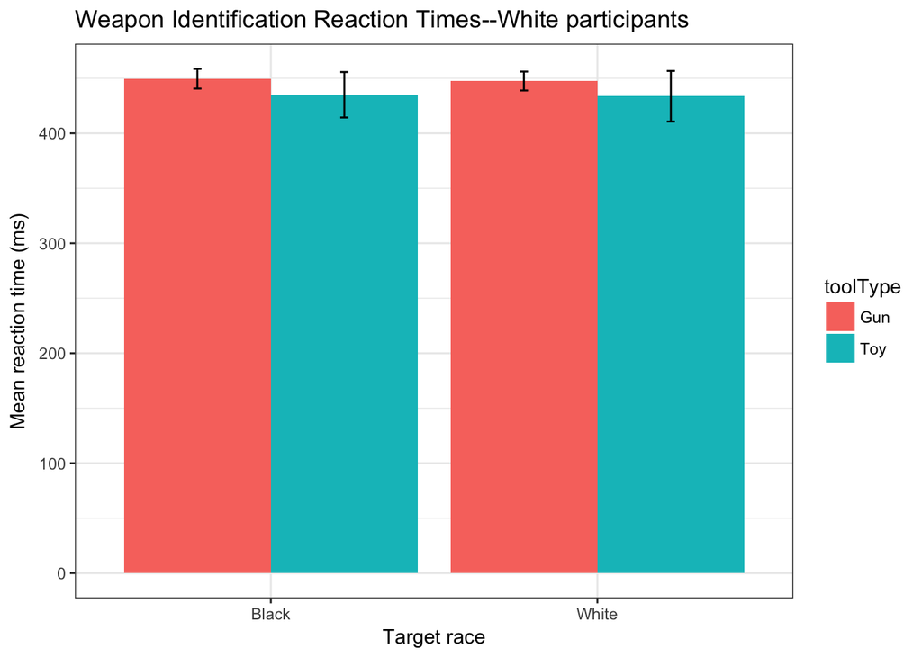

```r
ggplot(means.white, aes(x=targetRace, y=m, fill=toolType)) +
  geom_bar(stat="identity", position="dodge", width=.9) +
  geom_errorbar(limits, position=position_dodge(width=.9), width=0.05) +
  theme_bw() +
  ggtitle("Weapon Identification Reaction Times--White participants") +
  labs(x = "Target race", y = "Mean reaction time (ms)")
```

```r
#aov <- ezANOVA(data = d.complete.all, dv = log_rt, wid = workerid, within = .(targetRace, toolType), type = 2, detailed = TRUE)

#TRY AOV -> search within subject aov

# CALC PARTIAL ETA SQUARED LATER
```

[output not shown]

## Discussion

### Commentary

The original author commented on 1) The cover page of the study: “This task is investigating object recognition under distracting conditions. You will be asked to quickly identify objects will being distracted by other stimuli.”, 2) Warning message: “It might be helpful for participants if you warn them that they’ll see a message (an X) if they fail to respond quickly enough.”, and 3) Deviation: Requiring participants to press the spacebar between trials is one of the only deviations from the original procedure.